# Introduction to R and RStudio

Sulalitha Bowala

## Introduction

**R:**

- R is a programming language and environment primarily used for statistical analysis, data visualization, and data manipulation.
- R was created by statisticians and data scientists and is known for its extensive libraries for statistical modeling and data analysis.
- R is open-source, meaning it’s freely available for anyone to use and modify, and it has a large and active user community.
- R is particularly popular in academia, research, and industries that require advanced data analysis, such as finance, healthcare, and data science.

**RStudio:**

- RStudio is an integrated development environment (IDE) for the R programming language.
- It provides a user-friendly interface for writing, running, and debugging R code, making it easier for both beginners and experienced R users to work with R.
- RStudio includes features like a code editor, interactive data visualization, a console for running R code, and tools for managing projects and packages.
- RStudio simplifies the process of organizing your R projects and visualizing data, which is crucial for data analysis and research tasks.
- RStudio is available in both free and paid versions, with RStudio Desktop being the free, open-source version, and RStudio Server and RStudio Pro offering additional features for collaboration and enterprise use.

In summary, R is the programming language used for data analysis, while RStudio is the IDE that provides a convenient interface and tools for working with R, making it easier for data scientists, statisticians, and analysts to leverage the power of R for their work.

Visit here to install R and RStudio: https://posit.co/download/rstudio-desktop/

### RStudio Interface

Hopefully you have already downloaded and installed both R and RStudio. Here is how RStudio looks by default:

[figure not shown]

In order to have more usual setup to code in R, please follow the following steps:

- Step 1: Click on “File” (top left corner).
- Step 2: Click on “New File”.
- Step 3: Click on “R Script”.

It will open a new window in your RStudio.

[figure not shown]

RStudio has four windows (components):

- The Console (bottom left)
- The Source Editor / Script (top left)
- The Environment (top right)
- The Plot / Help Panel / File Explorer / Packages (bottom right)

[figure not shown]

Basic functions of each component:

- Console: The console is where R code is executed. You can type commands directly here and see the output immediately. It’s an interactive environment for testing and running code.
- Source Editor / Script: This is where you write and edit your R code. It provides features like syntax highlighting, code autocompletion, and indentation to make coding easier and more efficient.
- Environment: This panel displays information about the current R environment, including variables, data frames, and their values. You can also access a history of your R commands.
- The Plot / Help Panel / File Explorer / Packages: These tabs allow you to manage your project files, view and interact with plots and graphs, manage R packages, and access R documentation and help resources.

## Exploring R

### Arithmetic Operations (+,-,*,/)

R can be used as a simple calculator.

```r
2+3
```

```
## [1] 5
```

```r
5-7
```

```
## [1] -2
```

```r
7*15
```

```
## [1] 105
```

```r
35/7
```

```
## [1] 5
```

### Numeric Functions

R provides functions for typical mathematical tasks. To utilize a function, we simply enter its name, succeeded by parentheses. The content enclosed within the parentheses is known as the function’s argument, which can be either a numeric value or a variable.

Calculate the square root:

```r
sqrt(16)
```

```
## [1] 4
```

Round a number to the nearest integer:

```r
round(7.3)
```

```
## [1] 7
```

```r
round(8.8)
```

```
## [1] 9
```

### Saving Variables

In R, it’s possible to save variables. Once these variables are stored, we have the option to retrieve them at a later time or perform operations with them.

To save variables in R, you specify the variable name, followed by <- and the corresponding value of the variable. It’s worth noting that you can also use the = symbol, but the left-arrow <- is the recommended convention. While you have flexibility in choosing variable names, they cannot contain spaces, begin with a number, or include specific reserved symbols.

Let’s say we want to save the value 2.5 in variable X.

```r
X <- 2.5
```

If we want to see the value of X, we just type X and press enter.

```r
X
```

```
## [1] 2.5
```

We can also do some mathematical operations with the variables instead of directly typing the value.

```r
X+1
```

```
## [1] 3.5
```

```r
X-0.25
```

```
## [1] 2.25
```

```r
X*3
```

```
## [1] 7.5
```

```r
X/0.5
```

```
## [1] 5
```

```r
sqrt(X)
```

```
## [1] 1.581139
```

```r
round(X)
```

```
## [1] 2
```

### Datasets / Vectors

The simplest way to input a single variable data set into R is to create a “vector.” We list all of our values, separated by commas, and we wrap the entire list of values in the function “c()”.

Suppose the following are the weights (in kg) of 20 ICM students:

$90, 83, 91, 86, 97, 78, 88, 81, 89, 92, 76, 95, 84, 75, 99, 79, 98, 87, 94, 100$

Suppose that we wish to save this dataset as a vector in R. We will name this vector studentWeights. Note that it is important when naming vectors to find a balance between name length, and clarity.

```r
StudentWeights <- c(90, 83, 91, 86, 97, 78, 88, 81, 89, 92, 76, 95, 84, 75, 99, 79, 98, 87, 94, 100)
```

We can view the created vector (dataset) by typing its name into the console.

```r
StudentWeights
```

```
##  [1]  90  83  91  86  97  78  88  81  89  92  76  95  84  75  99  79  98  87  94
## [20] 100
```

### Calculate mean (average)

R is equipped with a comprehensive set of functions for performing standard statistical computations.

The function “mean” calculates the arithmetic mean (i.e., the “average”) of a dataset.

For the student weight dataset we can calculate the mean weight.

```r
mean(StudentWeights)
```

```
## [1] 88.1
```

The mean weight is 88.1 kg. Note that this is much faster than doing the computations by hand.

### Histogram

R can be used to produce graphs in statistics. We will start with histogram. Recall that in histograms, the height of each bars represents the number of observations in that interval of values.

To create a basic histogram in R, we will use the function “hist”.

Suppose following are the number of units sold of a product in a store.

120 135 110 155 142 128 168 148 125 132 140 115

We will first save this dataset as a vector, and then create a histogram of it.

```r
Sales <- c(120, 135, 110, 155, 142, 128, 168, 148, 125, 132, 140, 115)
```

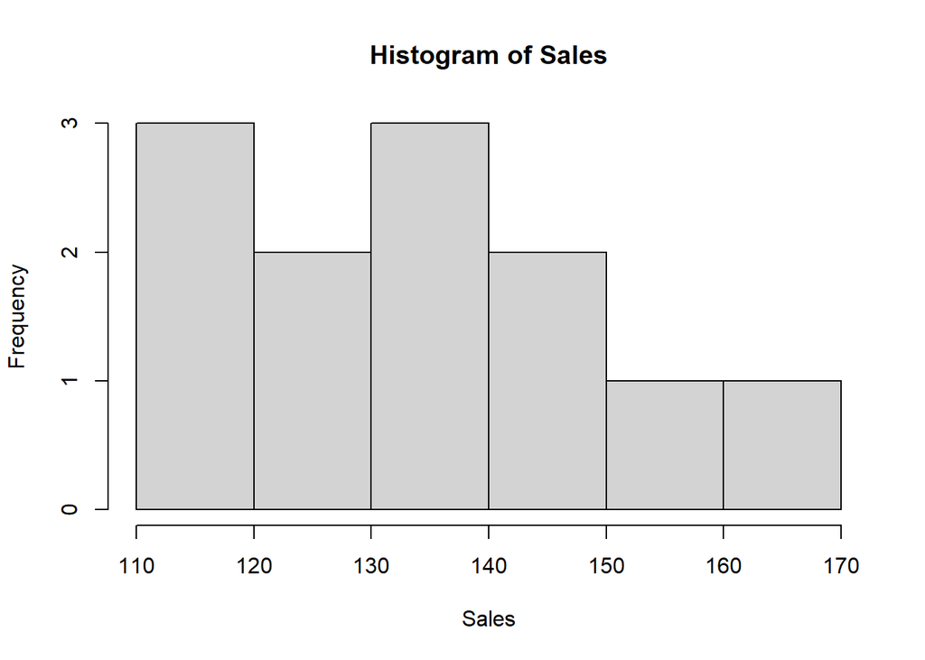

```r
hist(Sales)
```

We can calculate the mean of number of units sold.

```r
mean(Sales)
```

```
## [1] 134.8333
```

## RMarkdown Setup and Installation

RMarkdown is a tool that enables users to effortlessly combine code and its corresponding output.

RMarkdown can be initiated by following steps:

- Step 1: Click on “File” (top left corner).
- Step 2: Click on “New File”.
- Step 3: Click on “R Markdown…”.
- Step 4: This will open up the window below

[figure not shown]

Set the Title to “Lab 1”, change the Author to your name, and set the Default Output Format to PDF.

- Step 5: Click “ok”
- Step 6: You may get the following popup

[figure not shown]

Select “Yes” and wait for the installation to finish. **Note it may take a few minutes**.

- Step 7: Run the following line of code in your console:

**tinytex::install_tinytex()**

This will install a package that allows you to create PDF documents. Wait for the installation to complete.

- Step 8: Once the installation is completed, you should see the following window:

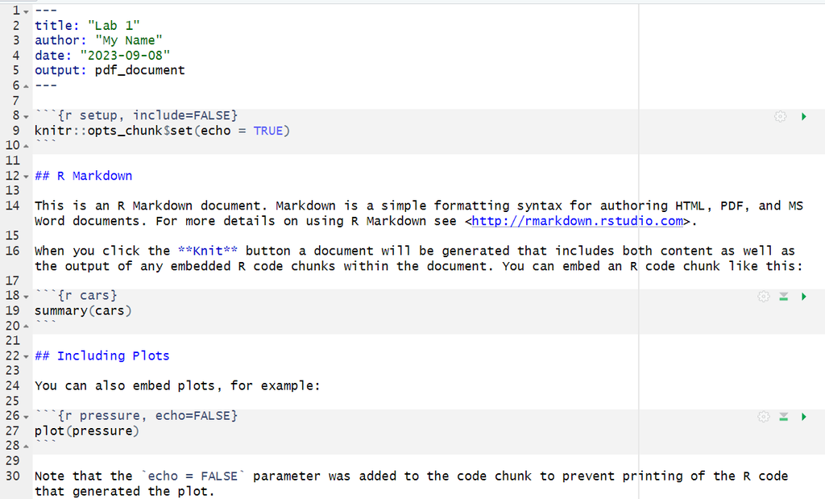

This is the default RMarkdown file. In order to make sure everything is installed correctly, you have to click “Knit” at the top of the RStudio window. Note that the first time you knit a document, you will have to save the R Markdown file first. You can choose to save your document anywhere and under any name. However, it is in good practice to match the name to the title of your document.

If everything has gone well, after knitting, a window pops up with your created PDF file. The PDF file is automatically saved in the folder where you have the R markdown file, and the PDF file has the same name as the R markdown file.

If you make changes in the R markdown file, you can knit it again to see the updated PDF file. Note that every time you knit the R markdown file, it will replace the older PDF file with the new one.